# Reproducible Research: Peer Assessment 1

## Loading and preprocessing the data

```r
#Read the "activity.csv" file, from the "activity.zip" file, which I unzipped and placed in the same directory as the Rmarkdown file. By the way, this folder is also my working directory, which is previously set.

data <- read.csv("activity.csv", header = TRUE, sep = ",", na.strings="NA",
                 colClass=c("numeric","Date","numeric"))
```

## What is mean total number of steps taken per day?

1. Make a histogram of the total number of steps taken each day (ignore the missing values)
2. Calculate and report the mean and median total number of steps taken per day

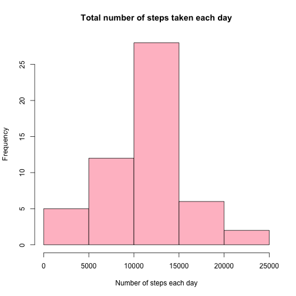

```r
#Create a new dataset without the missing values
dataclean = data[!is.na(data$steps), ]
#Aggregate this new dataset by sum of steps on each day
sumStep = aggregate(steps~date, dataclean, sum)
#Plot the number of steps
hist(sumStep$steps, col ="pink", main="Total number of steps taken each day", xlab="Number of steps each day")
```

```r
#Calculate the mean and reporte the value
mean = mean(sumStep$steps)
mean
```

```
## [1] 10766
```

```r
#Calculate the median and reporte the value
median = median(sumStep$steps)
median
```

```
## [1] 10765
```

## What is the average daily activity pattern?

- Make a time series plot (i.e. type = “l”) of the 5-minute interval (x-axis) and the average number of steps taken, averaged across all days (y-axis)

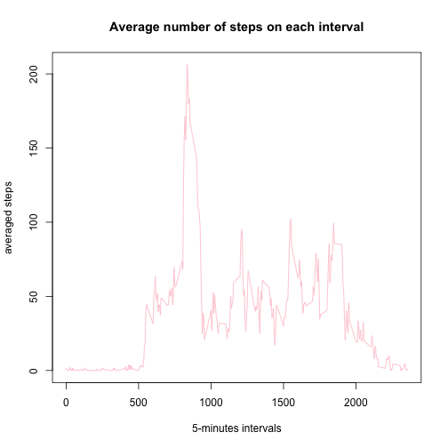

```r
#Aggregate the dataset without the missing values by mean of steps for each interval
meanStep = aggregate(steps~interval, dataclean, FUN="mean")
#Plot the intervals on the x-axis and the averaged steps on the y-axis
plot(meanStep$interval, meanStep$steps, type = "l", col = "pink",
     main = "Average number of steps on each interval",
     xlab = "5-minutes intervals",
     ylab = "averaged steps")
```

- Which 5-minute interval, on average across all the days in the dataset, contains the maximum number of steps?

```r
max.steps <- meanStep[which.max(meanStep$steps),1]
max.steps
```

```
## [1] 835
```

## Imputing missing values

- Calculate and report the total number of missing values in the dataset (i.e. the total number of rows with NAs)

```r
missingValues <- nrow(data[is.na(data$steps), ])
missingValues
```

```
## [1] 2304
```

- Devise a strategy for filling in all of the missing values in the dataset and create a new dataset that is equal to the original dataset but with the missing data filled in.

```r
# As you remember, there are the "steps" variables that are missing, not the interval variables. I don't know if it's a good strategy but i've chosen to fill the missing values with the mean of the intervals'days on which the steps are missing.
datafull <- data
for (i in 1:nrow(datafull)) {
        if (is.na(datafull$steps[i])) {
                datafull$steps[i] <- mean(data$interval)
        }
}
```

- Report the mean and median total number of steps taken per day

```r
#Aggregate this new dataset by sum of steps on each day
sumStepfull = aggregate(steps~date, datafull, sum)
#Calculate the mean and reporte the value
mean = mean(sumStepfull$steps)
mean
```

```
## [1] 53829
```

```r
#Calculate the median and reporte the value
median = median(sumStepfull$steps)
median
```

```
## [1] 11458
```

## Are there differences in activity patterns between weekdays and weekends?

- Create a new factor variable in the dataset with two levels – “weekday” and “weekend” indicating whether a given date is a weekday or weekend day.

```r
# Set the local system time.
Sys.setlocale(category = "LC_ALL", locale = "C")
```

```
## [1] "C/C/C/C/C/fr_CH.UTF-8"
```

```r
datafull$weektime <- as.factor(ifelse(weekdays(datafull$date) %in% c("Saturday","Sunday"),"weekend", "weekday"))
```

- Make a panel plot containing a time series plot (i.e. type = “l”) of the 5-minute interval (x-axis) and the average number of steps taken, averaged across all weekday days or weekend days (y-axis).

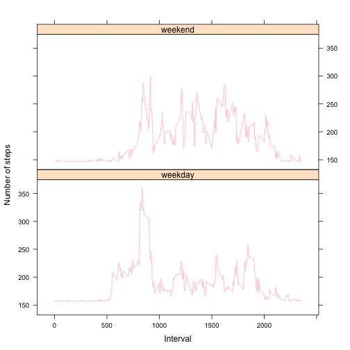

```r
#Aggregate the dataset by mean of steps for each interval
meanStep2 = aggregate(datafull$steps, by=list(datafull$interval, datafull$weektime),
                      FUN="mean")
names(meanStep2) <- c("interval", "weektime", "steps")
#Make the plot
library(lattice)
xyplot(meanStep2[, 3]~meanStep2[, 1]|meanStep2[, 2],
   type="l", col ="pink", ylab="Number of steps", xlab="Interval", layout = c(1,2))
```

On week-ends, there are more variation. On the weekdays, there are more steps, especially at the beginning of the day but with then less variation and less steps than for the week-end.